# Practical Machine Learning Project

## **Background**

Using devices such as Jawbone Up, Nike FuelBand, and Fitbit it is now possible to collect a large amount of data about personal activity relatively inexpensively. These type of devices are part of the quantified self movement – a group of enthusiasts who take measurements about themselves regularly to improve their health, to find patterns in their behavior, or because they are tech geeks. One thing that people regularly do is quantify how much of a particular activity they do, but they rarely quantify how well they do it. In this project, your goal will be to use data from accelerometers on the belt, forearm, arm, and dumbell of 6 participants. They were asked to perform barbell lifts correctly and incorrectly in 5 different ways. More information is available from the website here: http://groupware.les.inf.puc-rio.br/har (see the section on the Weight Lifting Exercise Dataset).

### Data

The training data for this project are available here:

https://d396qusza40orc.cloudfront.net/predmachlearn/pml-training.csv

The test data are available here:

https://d396qusza40orc.cloudfront.net/predmachlearn/pml-testing.csv

## **Exploring and Preprocessing Data**

First, we read in both training and testing data sets, and look at their dimensions.

```r
training <- read.csv('pml-training.csv', na.strings = c("NA", ""))
testing <- read.csv('pml-testing.csv', na.strings = c("NA", ""))
dim(training); dim(testing)
```

```
## [1] 19622   160
```

```
## [1]  20 160
```

The training data has 19622 rows and 160 columns, while the testing data has only 20 instances. (This seems suggest we need to further split the training data into traning and validation data sets for feature selection and model evaluation etc.)

Summaries on the datasets show that some columns only contain (or almost are) NA’s. So we calculate the percentages of NA’s in each column in both datasets, and plot the histogram of number of columns versus percentage of NA’s in each column. **It turns out there are only 60 *valid* columns where there is no NA’s, the other 100 columns are almost NA’s (>95%)**.

```r
summary(training)
summary(testing)
```

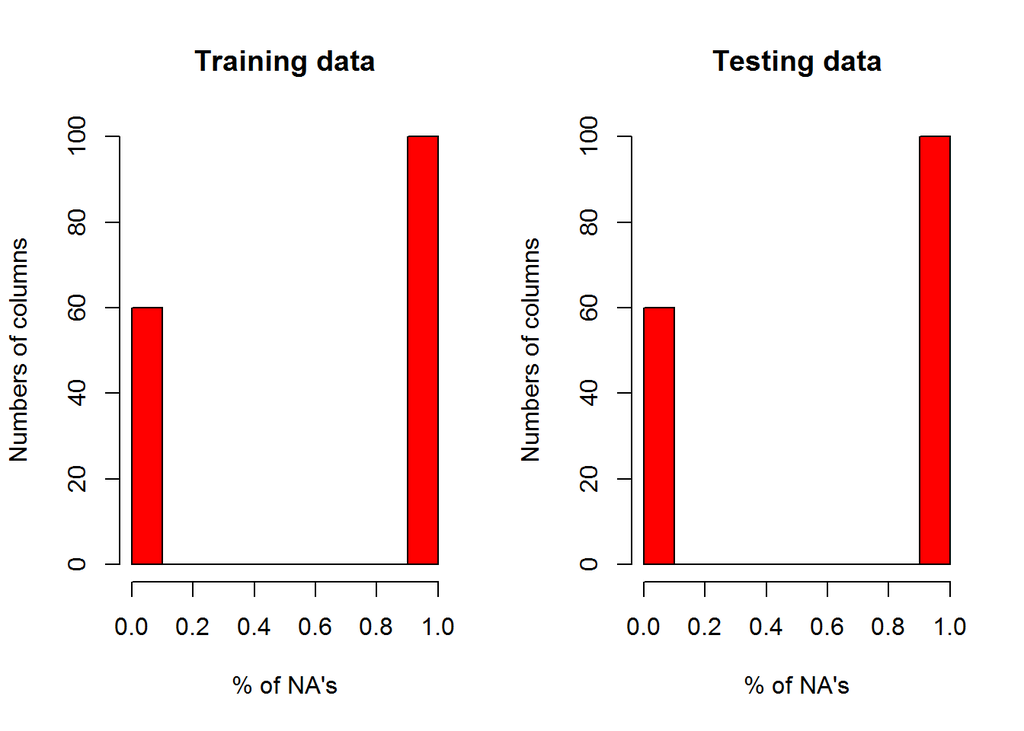

```r
training_na_percent <- data.frame(sapply(training, function(y) sum(length(which(is.na(y))))/nrow(training)))
testing_na_percent <- data.frame(sapply(testing, function(y) sum(length(which(is.na(y))))/nrow(testing)))
names(training_na_percent) <- c('NA.Percent')
names(testing_na_percent) <- c('NA.Percent')
par(mfrow=c(1,2))
hist(training_na_percent$NA.Percent, main='Training data', col='red', xlab='% of NA\'s', ylab='Numbers of columns')
hist(testing_na_percent$NA.Percent, main='Testing data', col='red', xlab='% of NA\'s', ylab='Numbers of columns')
```

Therefore, we remove those NA columns from both traning and testing datasets. The new dimensions of datasets are 19622x60 and 20x60 respectively.

```r
training <- training[, training_na_percent$NA.Percent<0.95]
testing <- testing[, testing_na_percent$NA.Percent<0.95]
dim(training); dim(testing)
```

```
## [1] 19622    60
```

```
## [1] 20 60
```

Another finding on the datasets is that the first 7 columns are IDs, usernames, timestamps, etc. which are not really relevant for the prediction.

```r
summary(training[,1:7])
```

```
##        X            user_name    raw_timestamp_part_1 raw_timestamp_part_2
##  Min.   :    1   adelmo  :3892   Min.   :1.322e+09    Min.   :   294
##  1st Qu.: 4906   carlitos:3112   1st Qu.:1.323e+09    1st Qu.:252912
##  Median : 9812   charles :3536   Median :1.323e+09    Median :496380
##  Mean   : 9812   eurico  :3070   Mean   :1.323e+09    Mean   :500656
##  3rd Qu.:14717   jeremy  :3402   3rd Qu.:1.323e+09    3rd Qu.:751891
##  Max.   :19622   pedro   :2610   Max.   :1.323e+09    Max.   :998801
##
##           cvtd_timestamp  new_window    num_window
##  28/11/2011 14:14: 1498   no :19216   Min.   :  1.0
##  05/12/2011 11:24: 1497   yes:  406   1st Qu.:222.0
##  30/11/2011 17:11: 1440               Median :424.0
##  05/12/2011 11:25: 1425               Mean   :430.6
##  02/12/2011 14:57: 1380               3rd Qu.:644.0
##  02/12/2011 13:34: 1375               Max.   :864.0
##  (Other)         :11007
```

After removing the first 7 columns, the final dimensions of datasets are 19622x53 and 20x53 respectively.

```r
training <- training[, -c(1:7)]
testing <- testing[, -c(1:7)]
dim(training); dim(testing)
```

```
## [1] 19622    53
```

```
## [1] 20 53
```

Finally, we split the training data into 60% of training and 40% of validation.

```r
library(caret)
set.seed(1011)
inTrain <- createDataPartition(training$classe, p = 0.6, list = FALSE)
validation <- training[-inTrain, ]
training <- training[inTrain, ]
dim(training); dim(validation); dim(testing)
```

```
## [1] 11776    53
```

```
## [1] 7846   53
```

```
## [1] 20 53
```

## **Train the Random Forest model**

Random Forest seems very suitable for this kind of non-linear classification problem. To save the computation time, the number of trees to grow *ntree* is limited to 3.

```r
modFit <- train(classe~., data=training, method='rf', ntree=3)
modFit
```

```
## Random Forest
##
## 11776 samples
##    52 predictor
##     5 classes: 'A', 'B', 'C', 'D', 'E'
##
## No pre-processing
## Resampling: Bootstrapped (25 reps)
## Summary of sample sizes: 11776, 11776, 11776, 11776, 11776, 11776, ...
## Resampling results across tuning parameters:
##
##   mtry  Accuracy   Kappa      Accuracy SD  Kappa SD
##    2    0.8958828  0.8682569  0.007770459  0.009784852
##   27    0.9493468  0.9359214  0.003884363  0.004914596
##   52    0.9469850  0.9329383  0.006665640  0.008424283
##
## Accuracy was used to select the optimal model using  the largest value.
## The final value used for the model was mtry = 27.
```

The most importance feature seems to be **roll_belt**.

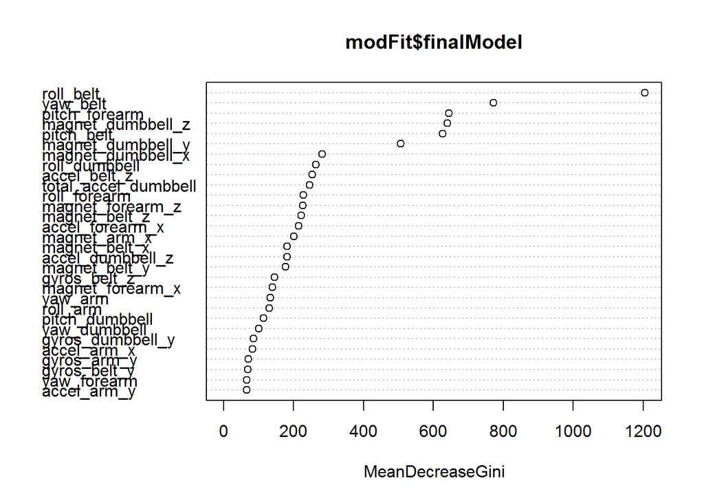

```r
varImpPlot(modFit$finalModel)
```

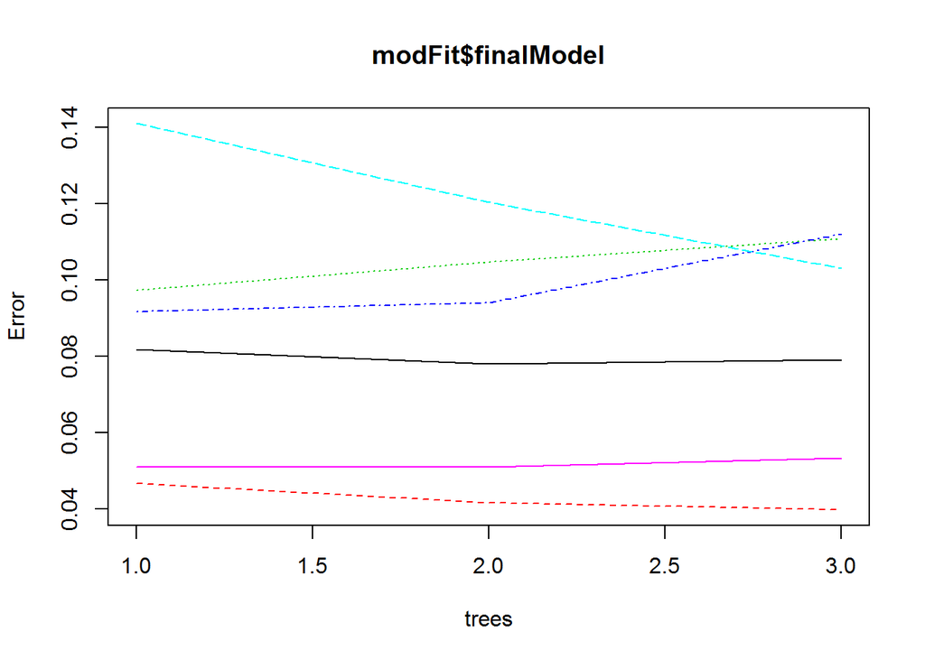

```r
plot(modFit$finalModel)
```

## **Validation Set**

We evaluate the model on validation set. A bit surprisingly the accurary on validation set is over **95%** even when the number of trees of grow was only 3.

```r
predValidation <- predict(modFit, validation)
cmValidation <- confusionMatrix(validation$classe, predValidation)
cmValidation$overall[1]
```

```
## Accuracy
## 0.967117
```

## **Predict on Testing Set**

Finally, we predict on the testing set:

```r
predict(modFit, testing)
```

```
##  [1] B A B A A E D B A A B C B A E E A B B B
## Levels: A B C D E
```

*That’s it, thanks for reading!*